# Pretty Heatmaps

Nov. 25

## First things first

We will need the packages `RColorBrewer` and `pheatmap`:

- Check that `RColorBrewer` and `pheatmap` are installed
- If not, install them, then load them

```r
library(RColorBrewer)
library(pheatmap)
```

We also need the “fruits” data:

```r
data("fruits", package = "ReMUSE")
```

## Program

- Colors, with or without `RColorBrewer`
- Heatmaps with `pheatmap`

## Three ways to color objects

## Three ways to see colors

With integers, with color names or with an hexadecimal code (HEX)

| Integer | 1 | 2 | 3 | 4 |
| --- | --- | --- | --- | --- |
| Name | black | indianred2 | palegreen3 | dodgerblue2 |
| HEX | #000000 | #DF536B | #61D04F | #2297E6 |
| Integer | 5 | 6 | 7 | 8 |
| Name | turquoise | magenta3 | darkgoldenrod1 | gray62 |
| HEX | #28E2E5 | #CD0BBC | #F5C710 | #9E9E9E |

## Integers (rapide !)

The 8-color default palette in R.

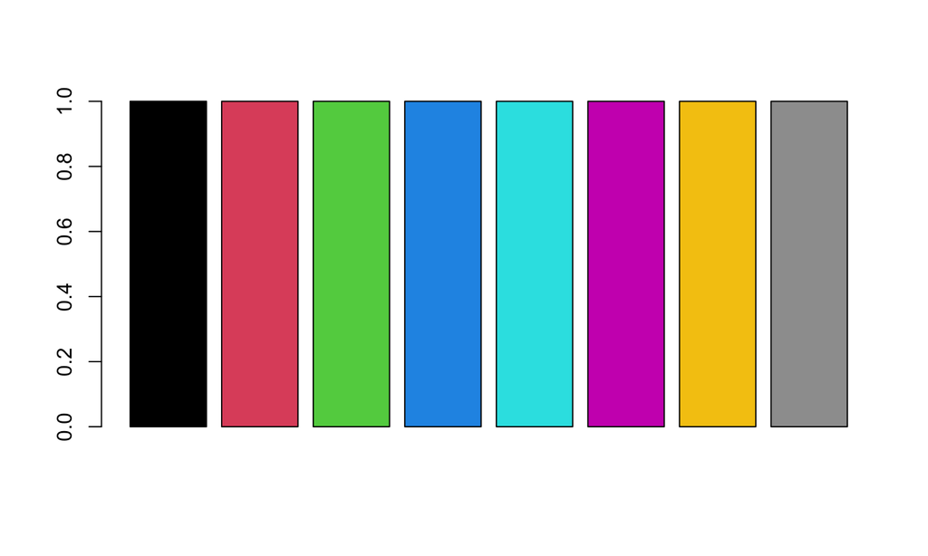

```r
barplot(rep(1,8), col = 1:8)
```

## Color names (more colors)

You can use color names (e.g. `"black"`, `"tomato"`, `"steelblue"`, `"darkorchid"` etc.)

One can access these names with the command `colors()` :

```r
sample(colors(), 7)
```

```
#> [1] "steelblue4" "lightcyan3" "gray15"     "steelblue1" "gray10"
#> [6] "cyan3"      "palegreen"
```

“Names” colors are used the same way as “integer” colors.

## HEX (even more colors !)

… with an hexadecimal code in the “Red - Green - Blue” color space:

- deux hexadecimals per base color (\(16 \times 16 = 256\) possible values)
- 0, 1, 2, 3, 4, 5, 6, 7, 8, 9, A, B, C, D, E, F
- Three base colors: red, green et blue
- 00 = none of this color
- FF = max of this color

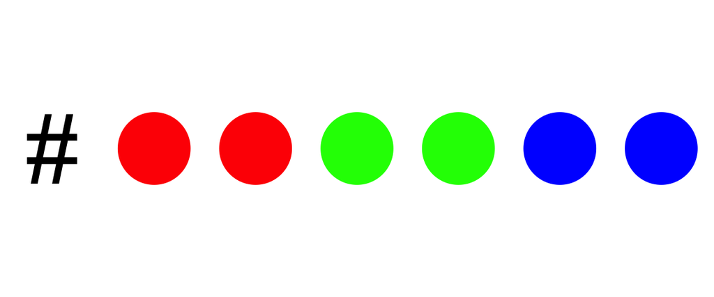

## Example

Three (almost) equivalent ways to obtain the following graph:

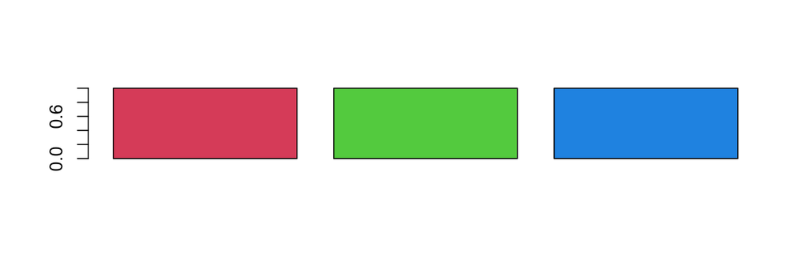

```r
barplot(rep(1, 3), col = 2:4)
barplot(rep(1, 3), col = c("indianred2", "palegreen3", "dodgerblue2"))
barplot(rep(1, 3), col = c("#DF536B", "#61D04F", "#2297E6"))
```

## Your turn!

Reproduce the graph below:

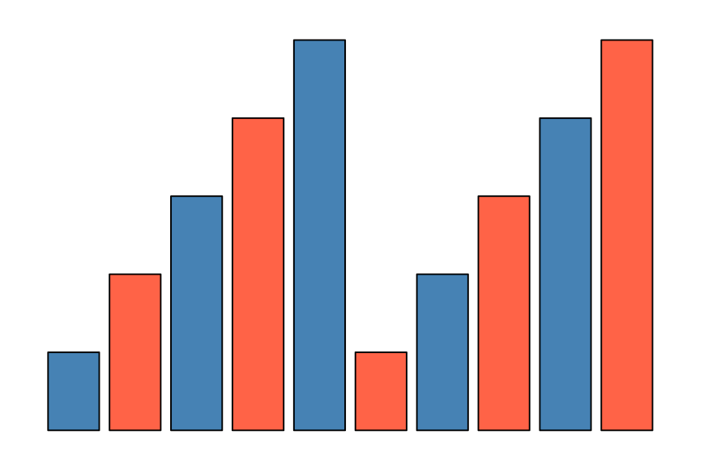

## CAUTION!

## Recycling is dangerous!

If there are more objects than colors, the colors will be recycled!

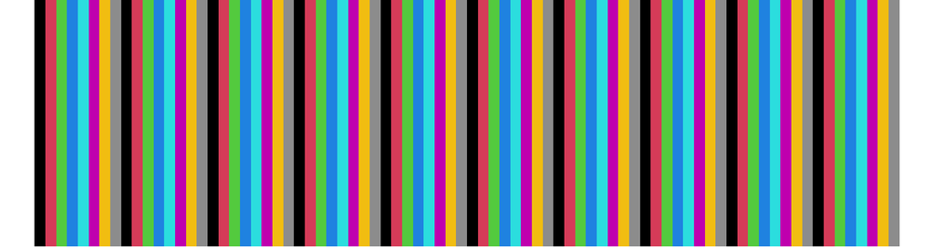

```r
par(mar = c(0, 0, 0, 0))
barplot(rep(1,80), col = 1:8, border = NA, space = 0, axes = FALSE)
```

## Palettes

## Use palettes

We will see **one** package in R that contains palettes: `RColorBrewer`.

The following command will display all the available palettes in `RColorBrewer`:

```r
display.brewer.all()
```

To get the colors from a specific palette:

```r
brewer.pal(n = 3, name = "Set3")
```

```
#> [1] "#8DD3C7" "#FFFFB3" "#BEBADA"
```

[figure not shown]

## In a few words

There are three types of palettes: sequential, diverging and qualitative.

1. **sequential** : to distinguish low values (light colors) to high values (dark colors)
2. **diverging** : low and high values are both dark colors, middle values are light colors
3. **qualitative**: adapted to coloring qualitative data

## Your turn

Complete the code to obtain the graph on the right:

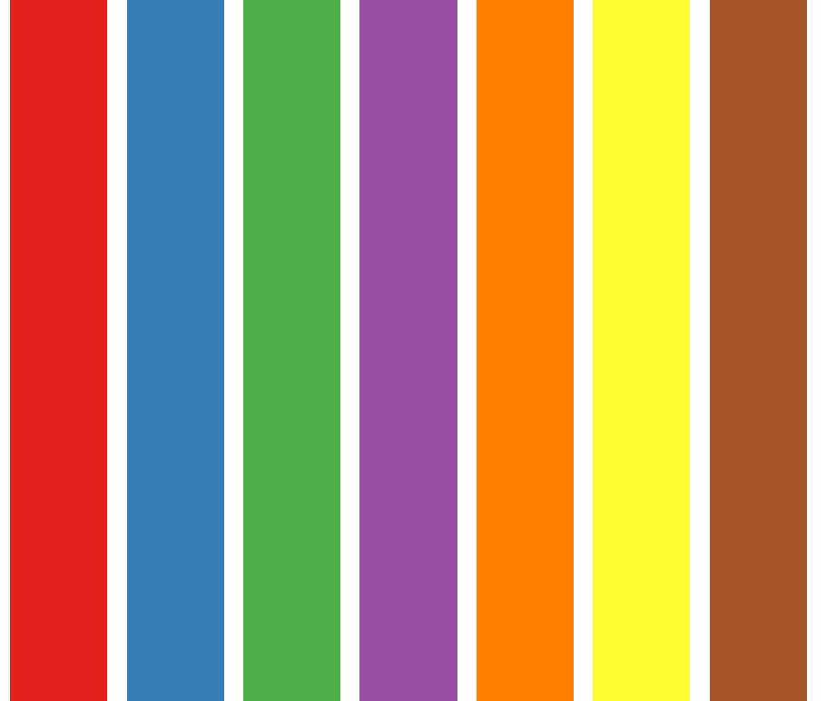

```r
pal <- brewer.pal(***, ***)
barplot(rep(1, 7),
        col = pal,
        axes = ***,
        border = ***)
```

## Heatmaps with `pheatmap`

## First try

```r
pheatmap(fruits)
```

```
Error in hclust(d, method = method) :
  NA/NaN/Inf dans un appel à une fonction externe (argument 10)
De plus : Warning messages:
1: In dist(mat, method = distance) :
  NAs introduits lors de la conversion automatique
2: In dist(mat, method = distance) :
  NAs introduits lors de la conversion automatique
```

## Why does it fail?

## Second try: better?

```r
pheatmap(fruits[, -(1:2)])
```

[output not shown]

## The arguments

- `cluster_rows = FALSE` : remove row dendrogram
- `scale = "column"` : standardize variables
- `show_rownames = FALSE` : hide row names
- `cellwidth = 10` : smaller cells

To get a complete list of all arguments: `?pheatmap`

## Thrd try

```r
pheatmap(
  fruits[, -(1:2)],
  cluster_rows = FALSE,
  scale = "column",
  show_rownames = FALSE,
  cellwidth = 10
)
```

[output not shown]

## Fourth try: change the colors

```r
colfun <- colorRampPalette(
  c("darkorchid",
    "white",
    "limegreen"))

pheatmap(
  fruits[, -(1:2)],
  cluster_rows = FALSE,
  scale = "column",
  show_rownames = FALSE,
  cellwidth = 10,
  color = colfun(20)
)
```

[output not shown]

## Fifth try: add “qualitative” information

```r
colfun <- colorRampPalette(
  c("darkorchid",
    "white",
    "limegreen"))
fruitsDF <- data.frame(
  fruits[,-1],
  row.names = make.unique(fruits$nom))
annotLignes <- fruitsDF[, "groupe",
                        drop = FALSE]

pheatmap(
  fruitsDF[, -1],
  cluster_rows = FALSE,
  scale = "column",
  show_rownames = FALSE,
  cellwidth = 10,
  color = colfun(20),
  annotation_row = annotLignes
)
```

[output not shown]

## Your turn!

Change the following command to get a pretty heatmap.

```r
pheatmap(
  t(fruits),
  scale = "row",
  color = c("black", "black"),
  legend_breaks = c(-6, 0,+6),
  border_color = "pink",
  cellheight = 100,
  cellwidth = 0.1,
  show_colnames = "FALSE"
)
```